# Practica_1

**Mauricio Montero**

## Regresión Lineal Simple (ventas por medio de comunicación)

Se va a realizar una predicción sobre los ingresos por venta, para ellos se le usara un conjunto de datos con información referente a las ventas obtenidos por medio de comunicación, se va a elegir una variable y realizar una regresión Simple Lineal.

# Paso 1: Carga de paquetes

```python
import pandas as pd
import numpy as np
import matplotlib.pyplot as plt
import seaborn as sns
from sklearn.model_selection import train_test_split
from sklearn.linear_model import LinearRegression
from sklearn.metrics import mean_squared_error, r2_score
```

# Paso 2: Carga del conjunto de datos y exploración de la información

```python
# Dicionario de columnas
column_names = {
    'Secuencia': 'Secuencia',
    'TV': 'TV',
    'Radio': 'Radio',
    'Periodico': 'Periodico',
    'Ventas': 'Ventas'
}

# Leemos el dataset
data = pd.read_csv('Publicidad.csv', names=column_names.values(), header=0)

# Explorar los primeros registros del conjunto de datos
print(data.head())

# Obtener informaciÃ³n sobre las columnas y los tipos de datos
print(data.info())

# Resumen estadÃstico de las variables numÃ©ricas
print(data.describe())

# Contar los valores Ãºnicos de cada columna
print(data.nunique())

print(data.head())
print(data.columns)
data.drop('Secuencia', axis=1, inplace=True)

data
```

```
   Secuencia     TV  Radio  Periodico  Ventas
0          1  230.1   37.8       69.2    22.1
1          2   44.5   39.3       45.1    10.4
2          3   17.2   45.9       69.3     9.3
3          4  151.5   41.3       58.5    18.5
4          5  180.8   10.8       58.4    12.9
<class 'pandas.core.frame.DataFrame'>
RangeIndex: 200 entries, 0 to 199
Data columns (total 5 columns):
 #   Column     Non-Null Count  Dtype
---  ------     --------------  -----
 0   Secuencia  200 non-null    int64
 1   TV         200 non-null    float64
 2   Radio      200 non-null    float64
 3   Periodico  200 non-null    float64
 4   Ventas     200 non-null    float64
dtypes: float64(4), int64(1)
memory usage: 7.9 KB
None
        Secuencia          TV       Radio   Periodico      Ventas
count  200.000000  200.000000  200.000000  200.000000  200.000000
mean   100.500000  147.042500   23.264000   30.554000   14.022500
std     57.879185   85.854236   14.846809   21.778621    5.217457
min      1.000000    0.700000    0.000000    0.300000    1.600000
25%     50.750000   74.375000    9.975000   12.750000   10.375000
50%    100.500000  149.750000   22.900000   25.750000   12.900000
75%    150.250000  218.825000   36.525000   45.100000   17.400000
max    200.000000  296.400000   49.600000  114.000000   27.000000
Secuencia    200
TV           190
Radio        167
Periodico    172
Ventas       121
dtype: int64
   Secuencia     TV  Radio  Periodico  Ventas
0          1  230.1   37.8       69.2    22.1
1          2   44.5   39.3       45.1    10.4
2          3   17.2   45.9       69.3     9.3
3          4  151.5   41.3       58.5    18.5
4          5  180.8   10.8       58.4    12.9
Index(['Secuencia', 'TV', 'Radio', 'Periodico', 'Ventas'], dtype='object')
```

|  | TV | Radio | Periodico | Ventas |
| --- | --- | --- | --- | --- |
| 0 | 230.1 | 37.8 | 69.2 | 22.1 |
| 1 | 44.5 | 39.3 | 45.1 | 10.4 |
| 2 | 17.2 | 45.9 | 69.3 | 9.3 |
| 3 | 151.5 | 41.3 | 58.5 | 18.5 |
| 4 | 180.8 | 10.8 | 58.4 | 12.9 |
| ... | ... | ... | ... | ... |
| 195 | 38.2 | 3.7 | 13.8 | 7.6 |
| 196 | 94.2 | 4.9 | 8.1 | 9.7 |
| 197 | 177.0 | 9.3 | 6.4 | 12.8 |
| 198 | 283.6 | 42.0 | 66.2 | 25.5 |
| 199 | 232.1 | 8.6 | 8.7 | 13.4 |

200 rows Ã— 4 columns

## Paso 3: Análisis exploratorio

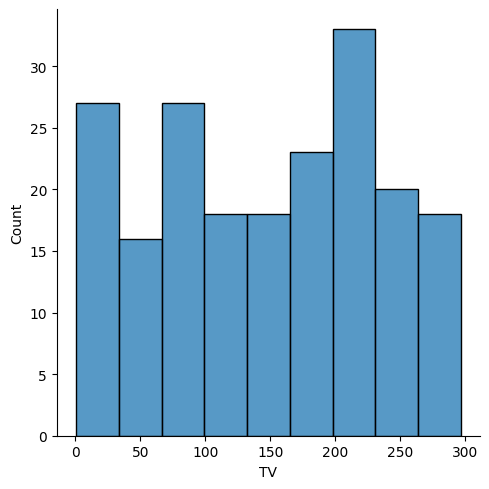

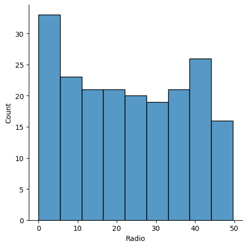

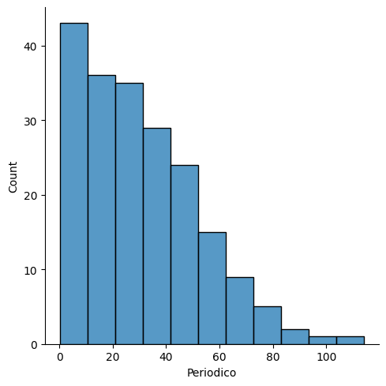

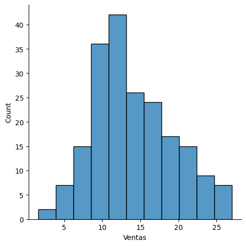

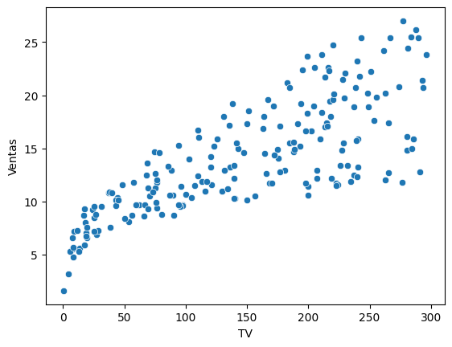

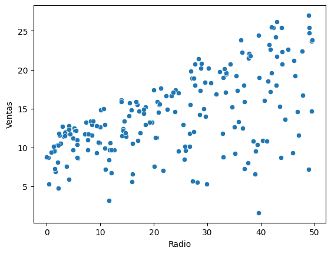

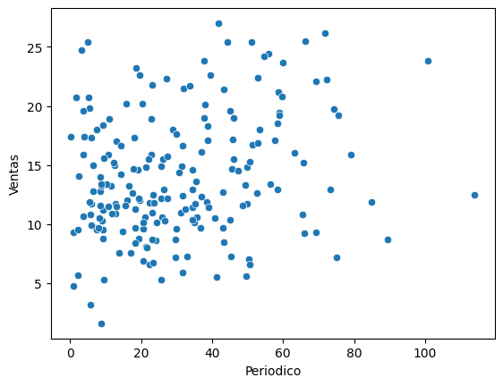

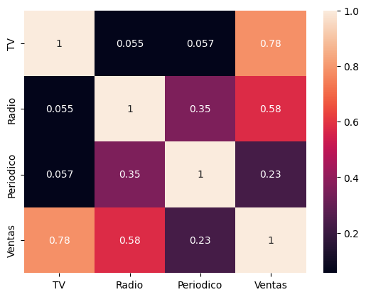

```python
# Visualizar la distribuciÃ³n de cada variable
sns.displot(data['TV'])
plt.show()

sns.displot(data['Radio'])
plt.show()

sns.displot(data['Periodico'])
plt.show()

sns.displot(data['Ventas'])
plt.show()

# RelaciÃ³n de la variable "sales" con las demÃ¡s variables
sns.scatterplot(x='TV', y='Ventas', data=data)
plt.show()

sns.scatterplot(x='Radio', y='Ventas', data=data)
plt.show()

sns.scatterplot(x='Periodico', y='Ventas', data=data)
plt.show()

# Matriz de correlaciÃ³n
correlation_matrix = data.corr()
sns.heatmap(correlation_matrix, annot=True)
plt.show()
```

## Paso 4: Elige la variable x

Analizamos la matriz de correlación obtenida en el paso anterior y seleccionamos la variable que tenga una correlación más significativa con la variable "Ventas" Y seleccionamos TV con 0.78 siendo la que tiene mas coorelacion

## Paso 5: Separación de los datos en conjuntos de entrenamiento y prueba

```python
#Definimos la variable a predecir
y = data['Ventas'].values
#Definimos feature
X = data['TV'].values.reshape(-1,1)


X_train, X_test, y_train, y_test = train_test_split(X, y, test_size=0.3)
```

## Paso 6: Creación del modelo de regresión lineal simple

```python
# Crear el modelo de regresiÃ³n lineal simple
model = LinearRegression()

# Entrenar el modelo utilizando el conjunto de entrenamiento
model.fit(X_train, y_train)
```

```
LinearRegression()
```

## Paso 7: Evaluación del modelo

```python
# Realizar predicciones en el conjunto de prueba
y_pred = model.predict(X_test)

# Calcular el error cuadrÃ¡tico medio (MSE)
mse = mean_squared_error(y_test, y_pred)
print('Error cuadrÃ¡tico medio (MSE):', mse)

# Calcular el coeficiente de determinaciÃ³n (R2-score)
r2 = r2_score(y_test, y_pred)
print('Coeficiente de determinaciÃ³n (R2-score):', r2)

print("El R cuadrado del modelo es: "+str(model.score(X_train,y_train)))

print("Los coeficientes de la funcion son: "+str(model.coef_))
rmse =np.sqrt(mean_squared_error(y_test,y_pred))
print("Root Mean Squared error: {}".format(rmse))
```

```
Error cuadrÃ¡tico medio (MSE): 10.529472562471996
Coeficiente de determinaciÃ³n (R2-score): 0.6718421450754145
El R cuadrado del modelo es: 0.5691046864580591
Los coeficientes de la funcion son: [0.04388232]
Root Mean Squared error: 3.2449148775387
```

## Plot

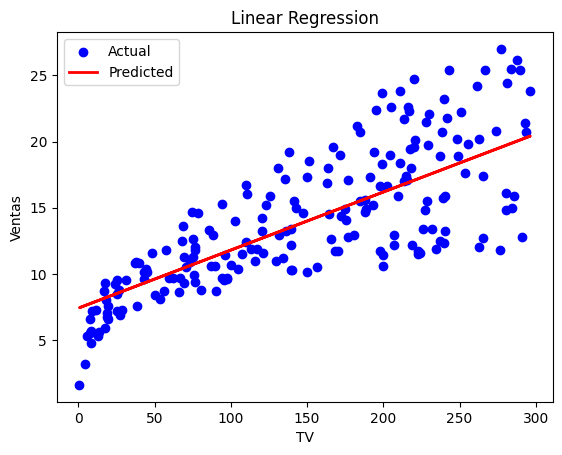

```python
X = data['TV'].values.reshape(-1,1)
y = data['Ventas'].values

y_pred = model.predict(X)

plt.scatter(X, y, color='blue', label='Actual')

# Plotting the predicted values
plt.plot(X, y_pred, color='red', linewidth=2, label='Predicted')

# Adding labels and title
plt.xlabel('TV')
plt.ylabel('Ventas')
plt.title('Linear Regression')
plt.legend()

# Display the plot
plt.show()
```

## Resultados:

1. El MSE es 10.529472562471996, lo que indica que el modelo tiene un error cuadrÃ¡tico medio de aproximadamente 10.53 en los valores predichos.
2. El R cuadrado es 0.6718421450754145, lo que sugiere que aproximadamente el 67.18% de la variabilidad en los datos de la variable dependiente se explica por el modelo.
3. El RMSE es 3.2449148775387, lo que significa que el modelo tiene un error promedio de aproximadamente 3.24 en las predicciones.